# Figures with individual subject points

Wanjia Guo

2023-12-18

# Behavioral Results

## Pre-scan

Participant were instructed to answer the expected destination for 3 times during the route: once at Same, once at Overlapping, and once at non-overlapping. They also indicated their confidence towards the choice (sure vs. unsure).

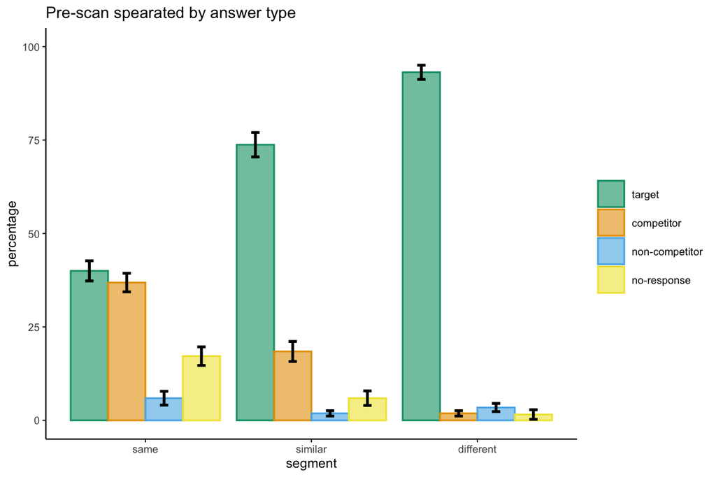

## scan

Performance during scan has a mean accuracy of 0.85 with a standard error of 0.02. The average percentage for confident correct is 0.69, with a standard error of 0.03.

# fMRI Results

### Segments

Fig 2.

Looking at 4 ROIs across 4 segments, linear mixed effect showed significant main effect of segment (F(3,585) = 34.445, p < 0.001) and roi (F(3, 585) = 379.397, p < 0.001), as well as a significant interaction (F(9,585) = 26.581 , p < 0.001). Within the hippocampus, CA1 and CA23DG also showed significant main effect of segment (F(3,273) = 2.8824, p = 0.036) and interaction between ROI and segment (F(3, 273) = 2.7793, p = 0.042).

One sampled t-test showed CA23DG is significantly lower than 0 at early-similar segment (t(39) = -2.8034, p = 0.008) but significantly higher than 0 at late-similar segment (t(39) = 2.0926, p = 0.04294). This showed abrupt change in CA23DG from early- to late-similar segment.

## Valid vs. Invalid (Different vs. Same state)

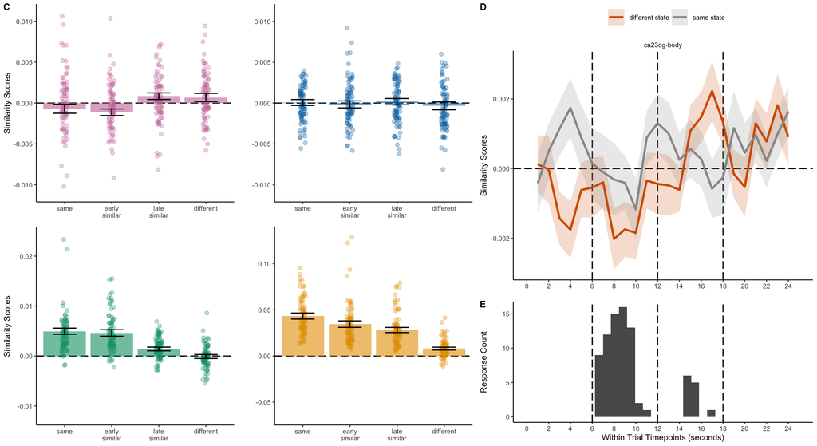

When testing all 4 ROIs, there is a significant interaction between ROIs and segment (F(9.585) = 2.29, p = 0.016) on the difference between same and different internal state.

**Problem? There is not a main effect of segment when looking at ca23dg alone (F(3,117) = 1.97, p = 0.122).**

An one-sample t-test also showed significant negative value between the difference of Different and Same states (t(39) = -2.7468, p = 0.009) when combined same and early-similar segments in CA23DG, with same internal state showing significantly higher pairmate similarities. This difference is absent for later half of the route (late-similar, different) (t(39) = 0.46914, p = 0.6416).

## MoI

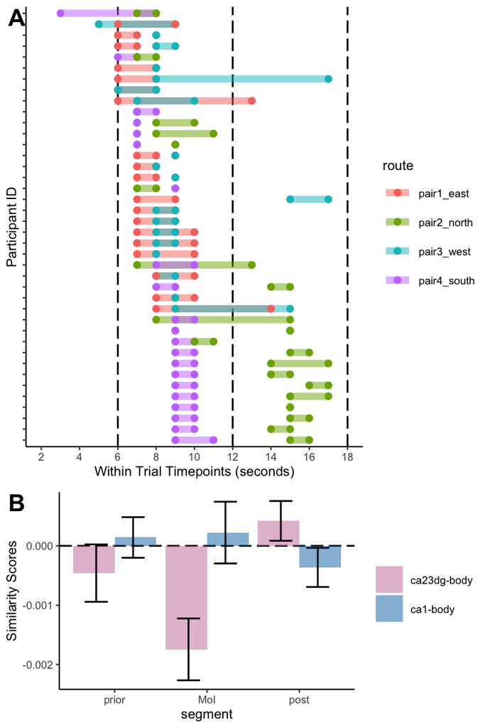

Linear mixed effect showed significant interaction between segments and ROIs, including CA1 and CA23DG (F(2, 195) = 5.4441, p = 0.005).

At MoI, CA23DG showed significant negative similarity scores (t(39) = -3.3482, p = 0.0018), which is significantly lower than POST (t(39) = -3.309, p = 0.002) via paired t-tests, but not significantly different from PRE (t(39) = -1.7661, p = 0.0852).

```
## Type III Analysis of Variance Table with Satterthwaite's method
##                   Sum Sq    Mean Sq NumDF DenDF F value  Pr(>F)
## segment       5.5754e-05 2.7877e-05     2   195  3.2489 0.04093 *
## valid         5.7389e-05 5.7389e-05     1   195  6.6882 0.01043 *
## segment:valid 4.2111e-05 2.1056e-05     2   195  2.4539 0.08861 .
## ---
## Signif. codes:  0 '***' 0.001 '**' 0.01 '*' 0.05 '.' 0.1 ' ' 1
```

```
##
##  One Sample t-test
##
## data:  (sub_p4 %>% filter(roi == "ca23dg-body" & valid == "valid-valid" & segment == "MoI"))$cor
## t = -3.3482, df = 39, p-value = 0.001812
## alternative hypothesis: true mean is not equal to 0
## 95 percent confidence interval:
##  -0.0027997171 -0.0006909711
## sample estimates:
##    mean of x
## -0.001745344
```

```
##
##  Paired t-test
##
## data:  (sub_p4 %>% filter(roi == "ca23dg-body" & valid == "valid-valid" & segment == "MoI"))$cor and (sub_p4 %>% filter(roi == "ca23dg-body" & valid == "valid-invalid" & segment == "MoI"))$cor
## t = -2.4001, df = 39, p-value = 0.02126
## alternative hypothesis: true difference in means is not equal to 0
## 95 percent confidence interval:
##  -0.0039205016 -0.0003345394
## sample estimates:
## mean of the differences
##            -0.002127521
```

```
##
##  Paired t-test
##
## data:  (sub_p4 %>% filter(roi == "ca23dg-body" & valid == "valid-valid" & segment == "MoI"))$cor and (sub_p4 %>% filter(roi == "ca23dg-body" & valid == "valid-valid" & segment == "post"))$cor
## t = -3.309, df = 39, p-value = 0.002021
## alternative hypothesis: true difference in means is not equal to 0
## 95 percent confidence interval:
##  -0.0034899876 -0.0008419617
## sample estimates:
## mean of the differences
##            -0.002165975
```